# Basic Risk Modeling Simulation

mwelz

6/25/2020

## Introduction

The idea is to generate a very simple simulation setup. If the risk modeling fails here, it will also fail in more complex setups.

We first load and define some helper functions.

```r
rm(list = ls()) ; cat("\014")
```

```r
# load the helper functions
source(paste0(getwd(), "/rm-funs/rm-funs.R"))

# define the logistic function
logistic <- function(x){1 / (1 + exp(-x))}
```

## Data Generation

We first define the sample size to $n = 10,000$ and draw $p = 5$ independent zero-mean covariates from the multivariate normal distribution. We also define a constant factor `tau` that is the basis of the average treatment effect and randomly draw a treatment assignment `w` to emulate an RCT.

```r
set.seed(1)
n <- 10000
p <- 5

# treatment assignment (assume RCT)
w <- rbinom(n, 1, 0.5)

# true treatment effect
tau <- -2

# covariates
x <- mvtnorm::rmvnorm(n, mean = rep(0, p), sigma = diag(p))
```

Next, we define coefficients `theta` and define the process that generates scores with and without the treatment effect as follows:

$$z_i(1) = \tau + \mathbf{z}_i^\top \theta + \varepsilon_i$$
$$z_i(0) = \mathbf{z}_i^\top \theta + \varepsilon_i$$

We then transform these scores to probabilities and use these probabilities to draw the binary outcome from a binomial distribution. We then use treatment asisgnment `w` to make sure that there is only one outcome `y` (the observed outcome) for each individual. The bottom line of this data generating process is that data is generated linearly and the influence of the treatment is constant. Hence, this setup is the easiest setup possible.

```r
# coefficients (including an intercept)
theta <- c(0.2, 0.5, -0.3, 0.7, -0.1, 0.4)

# compute Pr(Y = 1 | X) for each individual (with noise)
eps <-  rnorm(n, mean = 0, sd = 0.5)
pi1 <- logistic(tau + as.numeric(cbind(1, x) %*% theta) + eps)
pi0 <- logistic(as.numeric(cbind(1, x) %*% theta) + eps)
hte <- pi1 - pi0

# true ATE
ate <- mean(pi1) - mean(pi0)

# create binary outcomes. Equals 1 if individual died.
y0 <- rbinom(n, 1, pi0)
y1 <- rbinom(n, 1, pi1)
y  <- ifelse(w == 1, y1, y0) # observed outcome
```

## Analysis

We first run a sanity check to verify that we can obtain an accurate estimate of the ATE by taking the difference of average mortality within each group.

```r
# sanity check
ate.hat <- mean(y[w==1]) - mean(y[w==0])
ate.hat - ate # accurate estimation!
```

```
## [1] -0.004245201
```

Then we perform risk modeling.

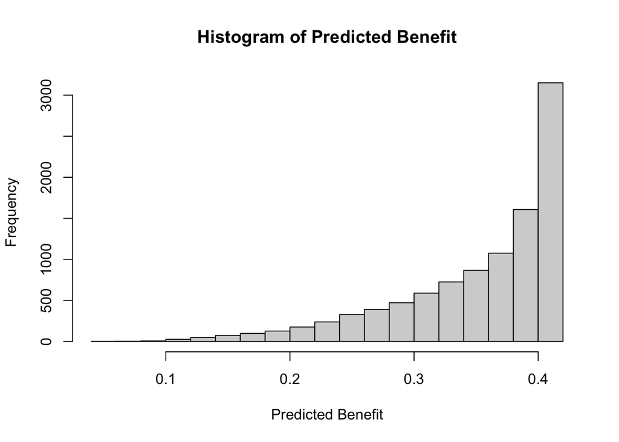

```r
# risk modeling
risk.model <- risk.modeling(X = x, w = w, y = y, alpha = 1, offset.lp = TRUE)

# histogram of predicted benefit
hist(risk.model$predicted.benefit, main = "Histogram of Predicted Benefit", xlab = "Predicted Benefit")
```

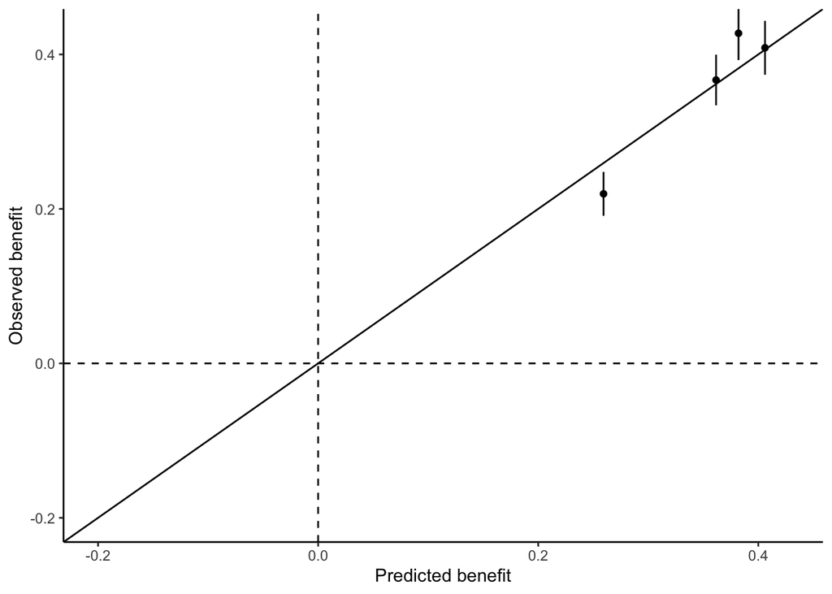

```r
# calibration plot with the 4 quartiles
calibration.plot(risk.model)
```

```r
# c index (based on second stage risk probabilities)
risk    <- transform.to.probability(risk.model$risk.regular.w)
c.index <- Hmisc::rcorr.cens(risk, y)[1] # TODO: implement this as function
c.index
```

```
##  C Index
## 0.799419
```

```r
# estimated ATE
risk.model$ate.hat - abs(ate) # accurate!
```

```
## [1] 0.001426391
```

```r
# observed and predicted beneefit by quartile group
benefits <- get.benefits(risk.model)
benefits$group.observed.benefit
```

```
##   quantile       mean     stderr       df
## 1    <=25% -0.4274080 0.01771683 2415.315
## 2 (25,50]% -0.4085941 0.01778234 2442.473
## 3 (50,75]% -0.3668770 0.01674166 2181.823
## 4     >75% -0.2195056 0.01448856 1910.790
```

```r
benefits$group.predicted.benefit
```

```
##   quantile      mean       stderr   df
## 1    <=25% 0.3820361 0.0008803341 2499
## 2 (25,50]% 0.4061305 0.0001496955 2499
## 3 (50,75]% 0.3616560 0.0003722247 2499
## 4     >75% 0.2593691 0.0010481266 2499
```

```r
# coefficients of 2nd stage
risk.model$coefficients.stage2 # coefficient of w is close to tau!
```

```
##             Estimated Coefficient
## (Intercept)             0.8009054
## w                      -1.7638634
## wlp                     0.1742356
```